# Extrapolated NH3 Emissions from Cattle Slurry

Lorenzo Benedetti

2026-03-17

## Analysis overview

Extrapolated NH3 emissions were analysed as a randomized complete block design. Block and treatment were included as fixed effects in the linear model

$$y_{ij} = \mu + B_i + T_j + \varepsilon_{ij},$$

where $B_i$ is the effect of block, $T_j$ is the effect of treatment, and $\varepsilon_{ij}$ is the residual error. Block was entered before treatment; therefore, the treatment effect was evaluated using a sequential Type I ANOVA after accounting for block. A block-by-treatment interaction was not fitted because there was only one observation for each block-by-treatment combination.

Pairwise treatment comparisons were based on block-adjusted estimated marginal means. Tukey’s method was used to adjust both the 95% confidence intervals and P values for the family of pairwise comparisons. Thus, the procedure used here is a Tukey-adjusted comparison of estimated marginal means, not a least significant difference test. The estimated contrasts and their confidence intervals are reported as unstandardized effect sizes in the original response units.

```r
rm(list = ls())

setwd(
  "/Users/lorenzobenedetti/Documents/GitHub/Benedetti-2026-N2O-AgroscenaNext/Rstudio/Dynamic chambers"
)

library(readxl)
library(dplyr)
library(ggplot2)
library(car)
library(emmeans)
library(performance)
library(knitr)
library(kableExtra)

data <- read_excel("N-NH3 extrapolated cattle.xlsx")

required_columns <- c(
  "TREATMENT",
  "BLOCK",
  "N-NH3 perc TAN"
)

missing_columns <- setdiff(required_columns, names(data))

if (length(missing_columns) > 0) {
  stop(
    "The following required columns are missing: ",
    paste(missing_columns, collapse = ", ")
  )
}

data <- data %>%
  rename(NH3_TAN = `N-NH3 perc TAN`) %>%
  filter(
    !is.na(TREATMENT),
    !is.na(BLOCK),
    !is.na(NH3_TAN)
  ) %>%
  mutate(
    TREATMENT = factor(TREATMENT),
    BLOCK = factor(BLOCK)
  )
```

## Experimental-design check

```r
design_table <- with(data, table(BLOCK, TREATMENT))

kable(
  design_table,
  caption = "Number of observations in each block-by-treatment combination"
) %>%
  kable_styling(full_width = FALSE, position = "center")
```

Number of observations in each block-by-treatment combination

| CSAA | CSH2SO4 | CSRAW |
| --- | --- | --- |
| 1 | 1 | 1 |
| 1 | 1 | 1 |
| 1 | 1 | 1 |

```r
if (any(design_table != 1)) {
  warning(
    paste(
      "The dataset does not contain exactly one observation",
      "for each block-by-treatment combination."
    )
  )
}
```

## Descriptive statistics

The following values are unadjusted descriptive statistics. Model-based, block-adjusted means and treatment contrasts are reported below.

```r
desc <- data %>%
  group_by(TREATMENT) %>%
  summarise(
    mean = mean(NH3_TAN),
    sd = sd(NH3_TAN),
    n = n(),
    se = sd / sqrt(n),
    .groups = "drop"
  )

kable(
  desc,
  digits = 3,
  caption = "Unadjusted descriptive statistics by treatment"
) %>%
  kable_styling(full_width = FALSE, position = "center")
```

Unadjusted descriptive statistics by treatment

| TREATMENT | mean | sd | n | se |
| --- | --- | --- | --- | --- |
| CSAA | 10.169 | 2.094 | 3 | 1.209 |
| CSH2SO4 | 10.259 | 2.533 | 3 | 1.462 |
| CSRAW | 17.351 | 1.353 | 3 | 0.781 |

## Fixed-effects randomized complete block model

```r
model <- lm(
  NH3_TAN ~ BLOCK + TREATMENT,
  data = data
)

model_information <- data.frame(
  Item = c(
    "Model formula",
    "Number of observations",
    "Residual degrees of freedom",
    "Residual standard deviation"
  ),
  Value = c(
    paste(deparse(formula(model)), collapse = " "),
    as.character(nobs(model)),
    as.character(df.residual(model)),
    formatC(sigma(model), digits = 4, format = "f")
  )
)

kable(
  model_information,
  caption = "Complete model specification and residual information"
) %>%
  kable_styling(full_width = FALSE, position = "center")
```

Complete model specification and residual information

| Item | Value |
| --- | --- |
| Model formula | NH3_TAN ~ BLOCK + TREATMENT |
| Number of observations | 9 |
| Residual degrees of freedom | 4 |
| Residual standard deviation | 1.6967 |

### Sequential Type I ANOVA

Because block appears before treatment in the model formula, the treatment test evaluates treatment after accounting for variation among blocks.

```r
anova_results <- anova(model)

kable(
  anova_results,
  digits = 4,
  caption = "Sequential Type I ANOVA for extrapolated NH3 emissions"
) %>%
  kable_styling(full_width = FALSE, position = "center")
```

Sequential Type I ANOVA for extrapolated NH3 emissions

|  | Df | Sum Sq | Mean Sq | F value | Pr(>F) |
| --- | --- | --- | --- | --- | --- |
| BLOCK | 2 | 13.7468 | 6.8734 | 2.3876 | 0.2078 |
| TREATMENT | 2 | 101.8940 | 50.9470 | 17.6972 | 0.0103 |
| Residuals | 4 | 11.5153 | 2.8788 | NA | NA |

### Model coefficients

The coefficient P values below are unadjusted comparisons with the reference levels. Inference concerning the overall treatment effect should be based on the ANOVA, whereas treatment-specific comparisons should be based on the Tukey-adjusted contrasts reported later.

```r
coefficient_results <- as.data.frame(summary(model)$coefficients)

kable(
  coefficient_results,
  digits = 4,
  caption = "Linear-model coefficients"
) %>%
  kable_styling(full_width = FALSE, position = "center")
```

Linear-model coefficients

|  | Estimate | Std. Error | t value | Pr(>&#124;t&#124;) |
| --- | --- | --- | --- | --- |
| (Intercept) | 8.9089 | 1.2647 | 7.0445 | 0.0021 |
| BLOCK2 | 2.9392 | 1.3854 | 2.1216 | 0.1012 |
| BLOCK3 | 0.8415 | 1.3854 | 0.6075 | 0.5763 |
| TREATMENTCSH2SO4 | 0.0897 | 1.3854 | 0.0648 | 0.9515 |
| TREATMENTCSRAW | 7.1822 | 1.3854 | 5.1843 | 0.0066 |

## Model diagnostics

Model assumptions were evaluated using residual-versus-fitted and normal Q-Q plots. The Shapiro-Wilk and median-centred Levene tests are supplied as supplementary diagnostic summaries. Because the number of replicates is small, these tests should be interpreted together with the graphical diagnostics rather than as proof that the assumptions are satisfied.

```r
shapiro_results <- shapiro.test(residuals(model))

shapiro_table <- data.frame(
  Test = "Shapiro-Wilk test of model residuals",
  W = unname(shapiro_results$statistic),
  P_value = shapiro_results$p.value
)

diagnostic_data <- data.frame(
  residual = residuals(model),
  treatment = model.frame(model)$TREATMENT
)

levene_results <- leveneTest(
  residual ~ treatment,
  data = diagnostic_data,
  center = median
)

levene_table <- data.frame(
  Test = "Median-centred Levene test of model residuals",
  Numerator_df = levene_results[1, "Df"],
  Denominator_df = levene_results[2, "Df"],
  F_value = levene_results[1, "F value"],
  P_value = levene_results[1, "Pr(>F)"]
)

kable(
  shapiro_table,
  digits = 4,
  caption = "Residual-normality diagnostic"
) %>%
  kable_styling(full_width = FALSE, position = "center")
```

Residual-normality diagnostic

| Test | W | P_value |
| --- | --- | --- |
| Shapiro-Wilk test of model residuals | 0.9013 | 0.2599 |

```r
kable(
  levene_table,
  digits = 4,
  caption = "Residual-variance diagnostic"
) %>%
  kable_styling(full_width = FALSE, position = "center")
```

Residual-variance diagnostic

| Test | Numerator_df | Denominator_df | F_value | P_value |
| --- | --- | --- | --- | --- |
| Median-centred Levene test of model residuals | 2 | 6 | 1.3737 | 0.3227 |

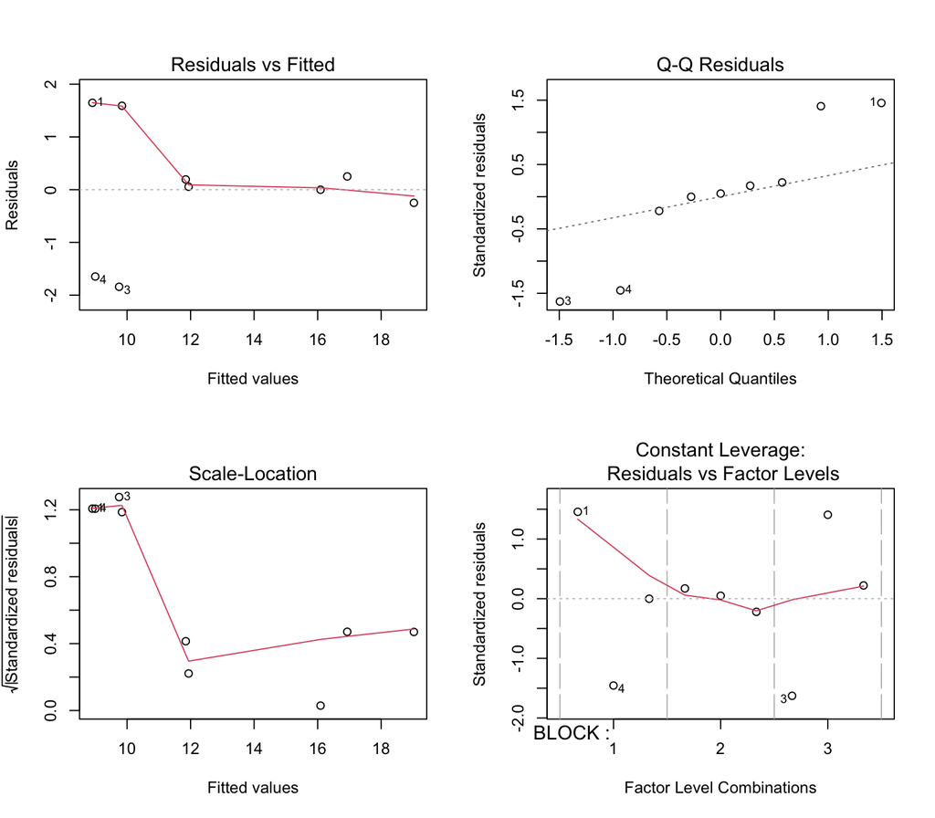

```r
par(mfrow = c(2, 2))
plot(model)
```

```r
par(mfrow = c(1, 1))
```

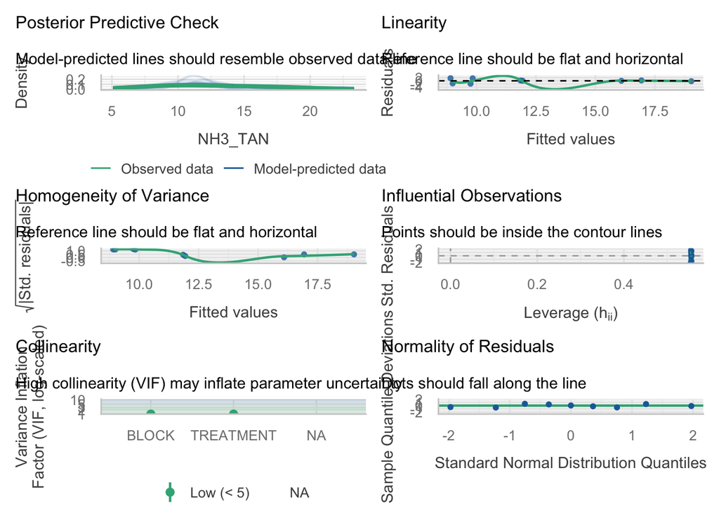

```r
check_model(model)
```

## Block-adjusted estimated marginal means

The confidence intervals in this table describe the uncertainty around each estimated marginal mean. The simultaneous Tukey-adjusted intervals required for treatment comparisons are provided in the following contrast table.

```r
emm_treatment <- emmeans(
  model,
  ~ TREATMENT
)

emm_results <- summary(
  emm_treatment,
  infer = c(TRUE, FALSE),
  level = 0.95
)

kable(
  as.data.frame(emm_results),
  digits = 4,
  caption = "Block-adjusted estimated marginal means with 95% confidence intervals"
) %>%
  kable_styling(full_width = FALSE, position = "center")
```

Block-adjusted estimated marginal means with 95% confidence intervals

| TREATMENT | emmean | SE | df | lower.CL | upper.CL |
| --- | --- | --- | --- | --- | --- |
| CSAA | 10.1691 | 0.9796 | 4 | 7.4493 | 12.8889 |
| CSH2SO4 | 10.2589 | 0.9796 | 4 | 7.5391 | 12.9786 |
| CSRAW | 17.3513 | 0.9796 | 4 | 14.6315 | 20.0711 |

## Tukey-adjusted treatment contrasts

The estimates below are differences between block-adjusted treatment means and therefore provide treatment effect sizes in the original response units. Both confidence intervals and P values use Tukey adjustment for the family of three pairwise comparisons.

```r
tukey_contrasts <- pairs(
  emm_treatment,
  adjust = "tukey"
)

contrast_results <- summary(
  tukey_contrasts,
  infer = c(TRUE, TRUE),
  level = 0.95,
  adjust = "tukey"
)

kable(
  as.data.frame(contrast_results),
  digits = 4,
  caption = paste(
    "Pairwise treatment contrasts with Tukey-adjusted",
    "95% confidence intervals and P values"
  )
) %>%
  kable_styling(full_width = FALSE, position = "center")
```

Pairwise treatment contrasts with Tukey-adjusted 95% confidence intervals and P values

| contrast | estimate | SE | df | lower.CL | upper.CL | t.ratio | p.value |
| --- | --- | --- | --- | --- | --- | --- | --- |
| CSAA - CSH2SO4 | -0.0897 | 1.3854 | 4 | -5.0271 | 4.8477 | -0.0648 | 0.9977 |
| CSAA - CSRAW | -7.1822 | 1.3854 | 4 | -12.1196 | -2.2448 | -5.1843 | 0.0144 |
| CSH2SO4 - CSRAW | -7.0924 | 1.3854 | 4 | -12.0298 | -2.1550 | -5.1196 | 0.0150 |

## Graphical presentation

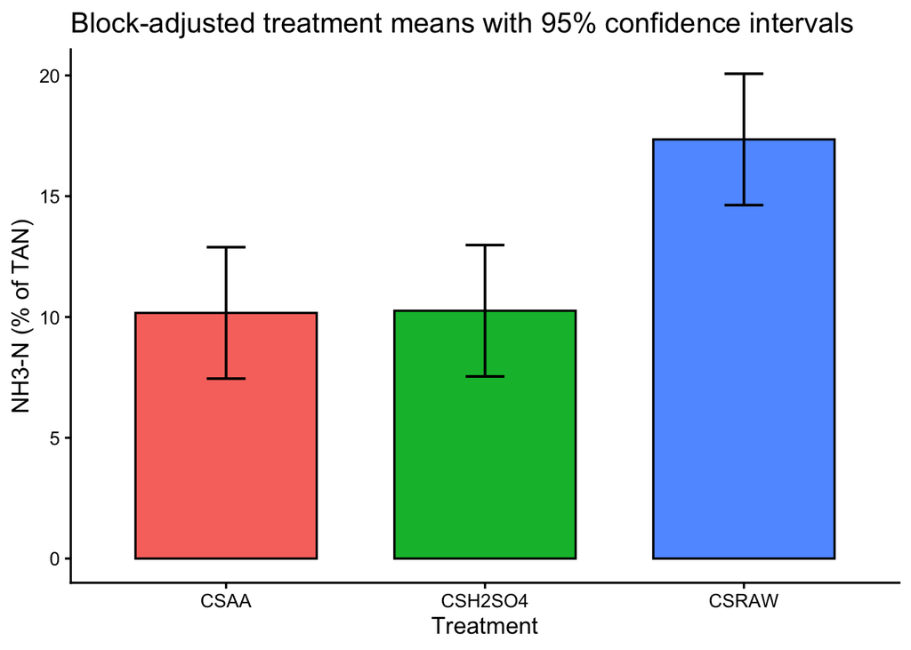

```r
emm_df <- as.data.frame(emm_results)

ggplot(
  emm_df,
  aes(
    x = TREATMENT,
    y = emmean,
    fill = TREATMENT
  )
) +
  geom_col(
    width = 0.7,
    color = "black"
  ) +
  geom_errorbar(
    aes(
      ymin = lower.CL,
      ymax = upper.CL
    ),
    width = 0.15,
    linewidth = 0.7
  ) +
  theme_classic(base_size = 13) +
  labs(
    x = "Treatment",
    y = "NH3-N (% of TAN)",
    title = "Block-adjusted treatment means with 95% confidence intervals"
  ) +
  theme(legend.position = "none")
```

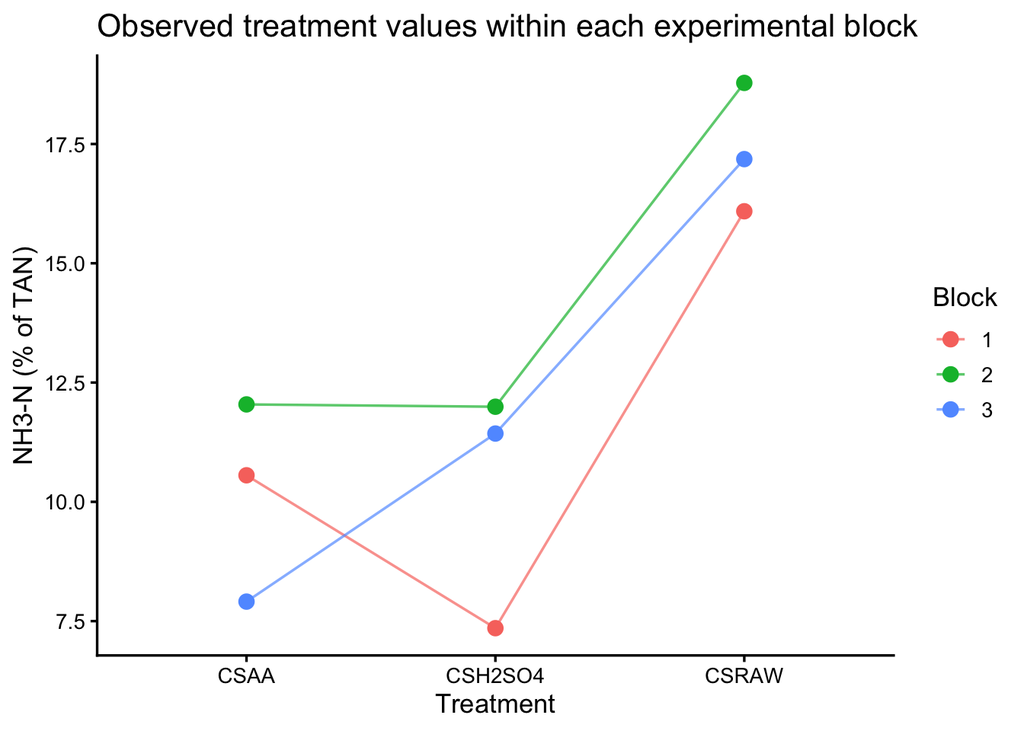

```r
ggplot(
  data,
  aes(
    x = TREATMENT,
    y = NH3_TAN,
    group = BLOCK,
    color = BLOCK
  )
) +
  geom_line(
    linewidth = 0.6,
    alpha = 0.7
  ) +
  geom_point(size = 3) +
  theme_classic(base_size = 13) +
  labs(
    x = "Treatment",
    y = "NH3-N (% of TAN)",
    color = "Block",
    title = "Observed treatment values within each experimental block"
  )
```